title: “Final project Sukker” author: “Kamilla Dalgaard, Joe Timmins, Asger Tonsberg og Christian Bæk” date: “2025-05-08” output: html_document —

We have used the API which delivers data from the Royal Danish Library’s newspaper collection. The data data from the Danish newspapers has to be older than 140 years to be “public data”. The API is presented in the Swagger UI and returns the data to us in JSON, JSONL and CSV formats. Requests to the API are based on search queries in the Mediestream-platform.

Technical documentation and explanations on with fields are exported can be found on the [Swagger UI](http://labs.statsbiblioteket.dk/labsapi/api//api-docs?url=/labsapi/api/openapi.yaml)

# Loading relevant libraries

The dataset is processed in the software programme R, offering various methods for statistical analysis and graphic representation of the results. In R, one works with packages each adding numerous functionalities to the core functions of R. In this example, the relevant packages are:

Documentation for each package:  
*https://www.tidyverse.org/packages/*  
https://cran.r-project.org/web/packages/tidytext/vignettes/tidytext.html  
*https://lubridate.tidyverse.org/*  
https://ggplot2.tidyverse.org/  
*https://cran.r-project.org/web/packages/ggwordcloud/vignettes/ggwordcloud.html

Additional information about R: https://www.r-project.org/

```r
library(tidyverse)
library(tidytext)
library(ggwordcloud)
library(urltools)
```

# Loading data from newspapers from 1850-1885 that have adverts about sugar in them.

The dataset is loaded into R via a retrieve link from the API. This link is created by the [Swagger UI](http://labs.statsbiblioteket.dk/labsapi/api//api-docs?url=/labsapi/api/openapi.yaml), which is documentation and user interface for the API.

```r
Sukker <- "https://labs.statsbiblioteket.dk/labsapi/api/aviser/export/fields?query=Sukker%20AND%20lplace%3AK%C3%B8benhavn%20py%3A%5B1850%20TO%201885%5D&fields=link&fields=recordID&fields=timestamp&fields=pwa&fields=cer&fields=fulltext_org&fields=pageUUID&fields=editionUUID&fields=titleUUID&fields=editionId&fields=familyId&fields=newspaper_page&fields=newspaper_edition&fields=lplace&fields=location_name&fields=location_coordinates&max=-1&structure=header&structure=content&format=CSV"
```

We will use the url_decode function to make the URL more readable. The URL is also stored in R:

```r
url_decode(Sukker)
```

```
## [1] "https://labs.statsbiblioteket.dk/labsapi/api/aviser/export/fields?query=Sukker AND lplace:København py:[1850 TO 1885]&fields=link&fields=recordID&fields=timestamp&fields=pwa&fields=cer&fields=fulltext_org&fields=pageUUID&fields=editionUUID&fields=titleUUID&fields=editionId&fields=familyId&fi…
```

Now it’s also able to see the query we used in mediastream.

Next step is to load our data into R using the read_csv function:

```r
Sukker_1850_1885 <- read_csv(Sukker)
```

## Analysing data from Mediestream-API

By doing this we can see as we targeted the news papers are from copenhagen and we have 82449 hits. This gives us some metadata about the newspapers.

```r
Sukker_1850_1885 %>%
  count(lplace, sort = TRUE)
```

```
## # A tibble: 1 × 2
##   lplace        n
##   <chr>     <int>
## 1 København 82449
```

We also have meta data on which newspapers the articles derives from:

```r
Sukker_1850_1885 %>%
  count(familyId, sort = TRUE)
```

```
## # A tibble: 15 × 2
##    familyId                       n
##    <chr>                      <int>
##  1 berlingsketidende          21200
##  2 dagbladetkoebenhavn1851    12597
##  3 adresseavisen1759          12199
##  4 nationaltidende             6926
##  5 dagensnyheder1868           6344
##  6 dagstelegraphen             5918
##  7 faedrelandet1834            5652
##  8 flyveposten                 3494
##  9 folketsavis1860             3350
## 10 morgenbladet1873            2743
## 11 aktuelt                     1118
## 12 morgenpostenkoebenhavn1844   677
## 13 kioebenhavnsposten1827       161
## 14 almuevennen1842               66
## 15 corsaren1840                   4
```

# Text mining:

```r
Sukker_tidy <- Sukker_1850_1885 %>%
  unnest_tokens(word, fulltext_org)
```

To clean the data more we loaded in a stopword list which will sort out all the most common words such as “at”, “det” etc. We got the stopwordlist from Max Odbjerg.

```r
stopord_1800 <- read_csv("https://gist.githubusercontent.com/maxodsbjerg/1537cf14c3d46b3d30caa5d99f8758e9/raw/9f044a38505334f035be111c9a3f654a24418f6d/stopord_18_clean.csv")
```

Using “anti_join” before “count” we can sort out the stop words. We did this to see how frequent the word “sukker” came up in the newspapers:

```r
Sukker_tidy %>%
  anti_join(stopord_1800) %>%
  count(word, sort = TRUE)
```

```
## # A tibble: 4,607,734 × 2
##    word       n
##    <chr>  <int>
##  1 kr     99814
##  2 sukker 99505
##  3 london 67862
##  4 hvede  59598
##  5 mai    45160
##  6 april  42199
##  7 aktier 40916
##  8 juni   40425
##  9 juli   40284
## 10 obl    40174
## # ℹ 4,607,724 more rows
```

As we can see sukker is quite frequent in the newspaper which could indicate it was advertised a lot

```r
Sukker_most_used <- Sukker_tidy %>%
  anti_join(stopord_1800) %>%
  count(word, sort = TRUE)
most_used_word <- Sukker_most_used %>%
  slice(1)

print(Sukker_most_used)
```

```
## # A tibble: 4,607,734 × 2
##    word       n
##    <chr>  <int>
##  1 kr     99814
##  2 sukker 99505
##  3 london 67862
##  4 hvede  59598
##  5 mai    45160
##  6 april  42199
##  7 aktier 40916
##  8 juni   40425
##  9 juli   40284
## 10 obl    40174
## # ℹ 4,607,724 more rows
```

```r
Sukker_most_used <- Sukker_tidy %>%
  anti_join(stopord_1800) %>%
  count(word, sort = TRUE)
most_used_word <- Sukker_most_used %>%
  slice(2)

print(most_used_word)
```

```
## # A tibble: 1 × 2
##   word       n
##   <chr>  <int>
## 1 sukker 99505
```

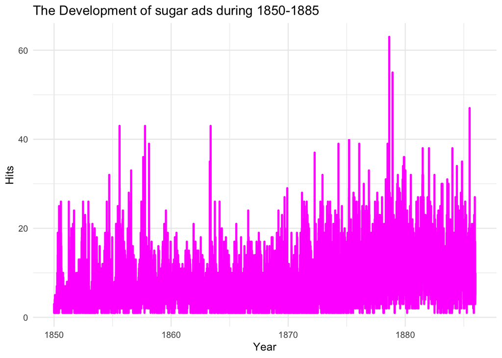

```r
#to make the graph we dowload the necesary packages dplyr will help us filter the word "tobak" and
# ggplot2 will make it possible for us to make graphs and add trend line.
library(dplyr)
library(ggplot2)

# Here we will filter for the word "tobak" and count per year
Sukker_over_time <- Sukker_tidy %>%
  filter(word == "sukker") %>%
  count(timestamp)

# Code for the Graph
sukker_plot <- ggplot(Sukker_over_time, aes(x = timestamp, y = n)) +
  geom_line(color = "magenta", size = 1) +
  labs(
    title = 'The Development of sugar ads during 1850-1885',
    x = "Year",
    y = "Hits"
  ) +  theme_minimal()
print(sukker_plot)
```

```r
#code for generating the picture
ggsave("sukker_over_time.png", plot = sukker_plot, width = 8, height = 6, dpi = 300)
```

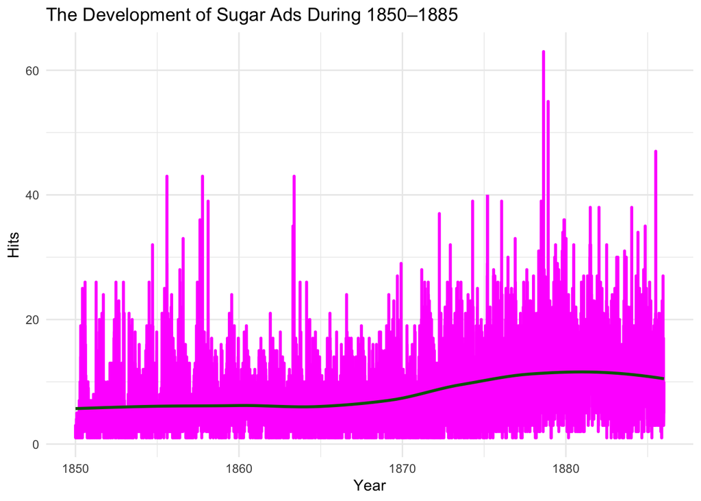

```r
#code for graph with trendline
sukker_plot_with_line <- ggplot(Sukker_over_time, aes(x = timestamp, y = n)) +
  geom_line(color = "magenta", size = 1) +
  geom_smooth(method = "loess", se = FALSE, color = "darkgreen", size = 1) +  # Trend line
  labs(
    title = 'The Development of Sugar Ads During 1850–1885',
    x = "Year",
    y = "Hits"
  ) +
  theme_minimal()

print(sukker_plot_with_line)
```

```r
ggsave("sukker_over_time_with_line.png", plot = sukker_plot_with_line, width = 8, height = 6, dpi = 300)
```